# Restaurant Review Analysis

## Restaurant Review Data

This Tripadvisor webpage provides users' reviews and ratings on a Tawau restaurant.

### Data source:

[Restaurant Review Data](https://www.tripadvisor.com.my/Restaurant_Review-g3533821-d8806165-Reviews-Good_View_Fresh_Seafood_Restaurant-Tawau_Tawau_Division_Sabah.html#REVIEWS)

## Analysis on Unstructured Online Review Data

1. Scrap data from webpage using **Beautiful Soup**
2. Perform natural language processing on **Review** data
3. Analyze sentiment of **Review** data using **nltk.sentiment**

### 1. Scrap data from webpage

### Check request status on URL

```python
from bs4 import BeautifulSoup
import re
import requests
import pandas as pd

url = 'https://www.tripadvisor.com.my/Restaurant_Review-g3533821-d8806165-Reviews-Good_View_Fresh_Seafood_Restaurant-Tawau_Tawau_Division_Sabah.html#REVIEWS'

#Set the User-Agent header
headers = {
    "User-Agent": "Mozilla/5.0 (Macintosh; Intel Mac OS X 10_15_7) AppleWebKit/537.36 (KHTML, like Gecko) Chrome/94.0.4606.71 Safari/537.36"
}

#Handle cookies
session = requests.Session()
response = session.get(url, headers=headers)
print(f'Response status code: {response.status_code}')
```

```
Response status code: 200
```

### Parse data using Beautiful Soup

```python
if response.status_code == 200:
    #Parse html structuce of webpage
    content = BeautifulSoup(response.content, 'html.parser')

    #Find all individual reviews
    reviews_container = content.find('div', class_='listContainer')
    reviews = reviews_container.find_all('div', class_='review-container')

else:
    print("Failed to retrieve the webpage")
```

### Extract restaurant name, reviews and ratings

```python
#Extract restaurant name
name = content.select("h1")
name = name[0].text.strip()
print(name)

review_texts = []
review_ratings = []

for review in reviews:
    # Extract review text
    review_text = review.find('p', class_='partial_entry').text.strip()
    review_texts.append(review_text)

    # Extract review rating
    rating_class = review.find('span', class_='ui_bubble_rating')['class'][1]
    rating = int(rating_class.split('_')[-1]) / 10
    review_ratings.append(rating)

df = pd.DataFrame({'Review': review_texts, 'Rating': review_ratings})

#Save DataFrame to CSV file
df.to_csv('restaurant_review.csv', index=False)
df.head()
```

```
Good View Fresh Seafood Restaurant
```

|  | Review | Rating |
| --- | --- | --- |
| 0 | Received recommendation from our taxi driver f... | 3.0 |
| 1 | Our group of friends opted for dinner at Good... | 3.0 |
| 2 | Nice place near the seaside, seafood very fres... | 4.0 |
| 3 | Mostly tourists will come here to eat seafood ... | 4.0 |
| 4 | Well, Despite its simple renovation, and hawke... | 4.0 |

##### Remark:

1) Restaurant name is extracted. 2) Reviews and ratings are extracted and combined into a single data frame. 3) Data frame is saved as CSV file for further analysis.

### 2. Perform natural language processing on **Review** data

### Lists of punctuations and stopwords

```python
#Punctuations to be removed
punctuations = '''\r\n!()-[]{};:'"\, <>./?@#$%^&*_~'''
```

```python
# #Option 1: Get English stop words from nltk
# import nltk
# from nltk.corpus import stopwords
# nltk.download('stopwords')
# stop_words = set(stopwords.words('english'))

#Option 2: Get stopwords from stopwords_url
stopwords_url = 'https://raw.githubusercontent.com/theleadio/datascience_demo/master/stopwords.txt'
response = requests.get(stopwords_url)
stop_words= response.text.splitlines()
```

### Remove punctuations and stopwords in Review data

```python
df = pd.read_csv("../DSproject/restaurant_review.csv")

review_filtered = []

for review in df['Review']:

  #Remove punctuations in raw 'Review'
  for character in review:
    if character in punctuations:
      review = review.replace(character, ' ')

  #Remove stopwords in raw 'Review'
  review = review.lower()
  tokens = review.split()
  tokens_filtered = [t for t in tokens if t not in stop_words]
  review = ' '.join(tokens_filtered)
  review_filtered.append(review)
```

##### Remark:

1) Filtered 'Review' data is prepared for sentiment analysis where punctuations and stopwords are removed.

### 3. Analyze sentiment of **Review** data

### Analyze sentiment using nltk.sentiment

```python
import nltk
from nltk.sentiment.vader import SentimentIntensityAnalyzer
nltk.download('vader_lexicon')

#Create analyzer for sentiment analysis
analyzer = SentimentIntensityAnalyzer()
```

```python
sentiment = []

for review in review_filtered:

  #Analyze sentiment in filtered 'Review'
  sentiments = analyzer.polarity_scores(review)
  sentiment.append(sentiments['compound'])
```

##### Remark:

1) Compound score of sentiments are selected for direct analysis instead of negative, neutral and positive score. It represents the overall sentiment of a review with mixed feeling.

### Study sentiment score relevancy

```python
#Attach "sentiment" list to dataframe
df['Sentiment'] = sentiment
df
```

|  | Review | Rating | Sentiment |
| --- | --- | --- | --- |
| 0 | Received recommendation from our taxi driver f... | 3.0 | 0.6808 |
| 1 | Our group of friends opted for dinner at Good... | 3.0 | 0.9153 |
| 2 | Nice place near the seaside, seafood very fres... | 4.0 | 0.7506 |
| 3 | Mostly tourists will come here to eat seafood ... | 4.0 | 0.6369 |
| 4 | Well, Despite its simple renovation, and hawke... | 4.0 | 0.8689 |
| 5 | This place is sucked, the seafood is pricy. We... | 2.0 | -0.1027 |
| 6 | Too expensive on the food, taste average and s... | 1.0 | -0.5994 |
| 7 | Steam ginger fish mixed with butter, feel weir... | 1.0 | 0.1531 |
| 8 | Ordered two single dished rice i.e buttered ch... | 4.0 | -0.5423 |
| 9 | The seafood is fresh and tasty. However, price... | 4.0 | 0.6369 |
| 10 | Very bad working altitude from\nMost of their ... | 3.0 | -0.8271 |
| 11 | This is a hawker style seafood restaurant. The... | 4.0 | 0.5574 |
| 12 | The restaurant is a food-hall style in the ope... | 4.0 | 0.0000 |
| 13 | We got the impression from previous reviews th... | 4.0 | 0.7184 |
| 14 | We were 18 person.\nTaste is good...also kind.... | 1.0 | -0.6249 |

```python
#Study sentiment score relevancy to 'Review'
df.loc[7,'Review']
```

```
'Steam ginger fish mixed with butter, feel weird. Curry chicken still acceptable, and the vegetables found a hair in there..'
```

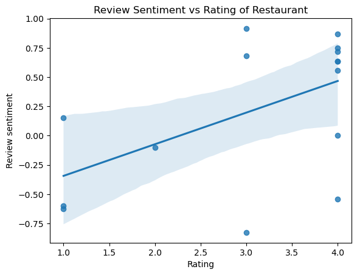

```python
#Study sentiment score relevancy to 'Rating'
import seaborn as sns
import matplotlib.pyplot as plt

x = df['Rating']
y = df['Sentiment']

sns.regplot(x=x, y=y)

plt.xlabel('Rating')
plt.ylabel('Review sentiment')
plt.title('Review Sentiment vs Rating of Restaurant')
plt.show()
```

##### Remark:

1) By referring to 'Review' column, some 'Sentiment' scores (between -1 and 1) become more relevant after stopwords are removed. Manual adjustment on the list of stopwords can be done to improve the relevancy. 2) Review sentiments have weak positive correlation to the rating from Tripadvisor users. This indicates that a single rating can not represent user's full expression and review sentiments should be taken into consideration when picking a restaurant.

## Save Restaurant Review Analysis for Future Reference

```python
#Save average score on rating and review sentiment of Tawau restaurant
average_rating = df['Rating'].mean()
average_sentiment = df['Sentiment'].mean()

restaurant = {
    'Name' : [name],
    'Rating' : [average_rating],
    'Review_sentiment' : [average_sentiment]
}

print(restaurant)
```

```
{'Name': ['Good View Fresh Seafood Restaurant'], 'Rating': [3.066666666666667], 'Review_sentiment': [0.21479333333333336]}
```

##### Remark:

1) This restaurant dictionary can be used to store review analysis data of other Tawau restaurants. Then, a simple restaurant recommendation system can be created using the restaurant dictionary.